# SSF for narwhals

Marie Auger-Méthé and Fanny Dupont

2026-01-16

# Set up

## Packages

```r
library(here) # to simplify data sharing
library(tidyverse)
library(ggpubr) # to put plots side-by-side
library(sf) # to handle spatial object
library(amt) # to prep data for ssf (and fit simpler ssf)
library(glmmTMB)
library(terra)
library(tidyterra)
library(kableExtra)
library(modelsummary)
options(modelsummary_factory_default = 'kableExtra') # New version has tinytable default option
options(modelsummary_factory_latex = 'kableExtra')
options(modelsummary_factory_html = 'kableExtra')
library(tinytable)
library(MuMIn) # for AICc
library(predicts) # For sampling starting locations
library(future.apply) # For parallel lapply
library(stringr) # For selection the good covariate name
library(brms) # von mises for UD
library(RSpectra)
library(Matrix)
```

## Narwhal data

```r
narwhals <- read.csv(file = file.path(here("Data/3_Narwhals/Movement"),
                                    "narwhals_clean.csv"))
head(narwhals)
```

```
##      ID        datetime_UTC release_datetime_UTC Healed.Scars    X_UTM   Y_UTM
## 1 17001 2017-08-02 00:00:20  2017-07-31 17:48:00        FALSE 517582.8 8033649
## 2 17001 2017-08-02 01:00:20  2017-07-31 17:48:00        FALSE 516507.6 8030323
## 3 17001 2017-08-02 02:00:20  2017-07-31 17:48:00        FALSE 511834.8 8027071
## 4 17001 2017-08-02 03:00:20  2017-07-31 17:48:00        FALSE 507817.2 8020915
## 5 17001 2017-08-02 04:00:20  2017-07-31 17:48:00        FALSE 506687.7 8016087
## 6 17001 2017-08-02 05:00:20  2017-07-31 17:48:00        FALSE 510194.3 8013067
```

Formatting some of the columns.

```r
# ID as factor
narwhals$ID <- as.factor(narwhals$ID)

# Make date time as date time object
narwhals$datetime_UTC <- ymd_hms(narwhals$datetime_UTC, tz="UTC")

narwhals$release_datetime_UTC <- ymd_hms(narwhals$release_datetime_UTC)
```

Check number of GPS locations per deployments and create data table.

```r
narwhal.data.table <- narwhals %>% group_by(ID) %>%
  summarize("Date of capture" = unique(date(release_datetime_UTC)),
            "N. of days" = as.numeric(round(max(datetime_UTC) - min(datetime_UTC),1)),
            "N. of locations" = length(ID),
            "Healed scars" = unique(Healed.Scars))
```

```r
cat(kable(narwhal.data.table,
          format="latex",
          caption="Narwhal data summary. We present the date of capture, the number of days and locations used in the analyses, and whether the individual had healed scars. Individual 18001 had a shorter time series because its tag only transmitted for 10 days.",
          booktabs = TRUE, linesep = "", row.names = FALSE),
    file = "narwhal_data_summary.tex")
```

Create a sf object for plotting. All of the layers should already projected in the EPSG:32617 (WGS 84 / UTM zone 17N) coordinate system.

```r
chosen.proj <- 32617
```

```r
narwhals.sf <- st_as_sf(narwhals, coords = c("X_UTM", "Y_UTM"),
                        remove = FALSE)
st_crs(narwhals.sf) <- chosen.proj
```

Load the land covariate.

```r
land <- st_read(file.path(here("Data/3_Narwhals/Covariates/NorthernBaffin_UTM"),
                          "NorthernBaffin_UTM.shp"))
```

# Function to prep data for ssf

```r
prep.data.ssf <- function(tracks, cov, fit.col.name = NULL, id.col.name = "id",
                          x.name = "X_UTM", y.name = "Y_UTM", t.name = "DatetimeLocal",
                          mask = NULL, dt = 15, n.random.extra = 50, n.avail = 30){


  # Create observed steps
  tracks.id <- tracks %>% nest(.by= c(!! sym(id.col.name), !!! syms(fit.col.name)))
  steps.id <- tracks.id %>%
    mutate(trk = map(data, function(d) {
      d %>% make_track(.x = !! sym(x.name), .y = !! sym(y.name), .t= !! sym(t.name)) %>%
        track_resample(rate = minutes(dt), tolerance = minutes(1)) %>% steps_by_burst()}))


  steps.avail <- steps.id
  steps.avail$rp <- NULL

  # We want the parameters used to create the control steps to be from the same distribution
  # We do not want the parameters to be taken for each individual separately
  data <- steps.avail %>%
    dplyr::select(!! sym(id.col.name), !!! syms(fit.col.name), trk) %>%
    unnest(cols= c(trk))
  gamma_par <-  data$sl_ %>% fit_distr("gamma")
  vonmises_par <- data$ta_ %>% fit_distr("vonmises")

  for(i in 1:nrow(steps.avail)){
    steps.avail[[i,"rp"]][[1]] <- steps.id[[i,"trk"]][[1]] %>%
      random_steps(n_control = n.random.extra,
                   sl_distr = make_gamma_distr(shape = gamma_par$params$shape,
                                               scale = gamma_par$params$scale,
                                               vcov = gamma_par$vcov),
                   ta_distr = make_vonmises_distr(kappa = vonmises_par$params$kappa,
                                                  vcov = vonmises_par$vcov))
  }


  for(i in seq_along(cov)){
    steps.avail <- steps.avail %>%
      mutate(rp = map(rp, function(d){
      extract_covariates(d,cov[[i]])}))
  }

  steps.avail <- steps.avail %>%
    dplyr::select(!! sym(id.col.name), !!! syms(fit.col.name), rp) %>%
    unnest(cols= c(rp))

  # Important: the `step_id_` will have erroneously similar names across individuals. We change the name here.
  steps.avail$step_id_ <- paste(steps.avail[[id.col.name]], steps.avail$step_id_, sep="_")
  steps.avail.sf <- st_as_sf(filter(steps.avail, !is.na(ta_)), coords = c("x2_", "y2_"), remove=FALSE)
  st_crs(steps.avail.sf) <- chosen.proj


  # Remove the control points that are in habitat that are masked (e.g., land for narwhals)
  for(i in seq_along(mask)){
    steps.avail.sf$mask <- rowSums(st_intersects(steps.avail.sf, mask[[i]], sparse=FALSE))
    steps.avail.sf <- subset(steps.avail.sf, !mask)
  }


  steps.avail.11 <- as.data.frame(steps.avail.sf) %>%
      group_by(step_id_) %>% filter(row_number() >= 1 & row_number() <= n.avail + 1)

  # Get the log sl and cos ta. And numeric case for poisson distribution
  steps.avail.11$ln_sl <- log(steps.avail.11$sl_)
  steps.avail.11$cos_ta <- cos(steps.avail.11$ta_)
  steps.avail.11$case_num <- as.numeric(steps.avail.11$case_)

  return(list(steps.id = steps.id, steps.avail = steps.avail.11,
              gamma_par=gamma_par, vonmises_par=vonmises_par))
}
```

We are using the land mask and 60 min time interval. This will take a few minutes to run.

While results tend to stabilize with a larger number of control points (`n.avail`), it takes a long time to run the analyses with 100 points. Thus, for a quick run through the code, one can change to a lower `n.avail` value.

```r
set.seed(78369)
narwhals.steps.avail <- prep.data.ssf(as.data.frame(narwhals.sf), cov = NULL,
                                    fit.col.name = "Healed.Scars",
                                    id.col.name ="ID", t.name = "datetime_UTC",
                                    mask= list(land), n.random.extra = 1200, n.avail = 100,
                                    dt = 60)
head(narwhals.steps.avail$steps.avail)
```

```
## # A tibble: 6 × 19
## # Groups:   step_id_ [1]
##   ID    Healed.Scars burst_     x1_     x2_      y1_      y2_   sl_    ta_
##   <fct> <lgl>         <dbl>   <dbl>   <dbl>    <dbl>    <dbl> <dbl>  <dbl>
## 1 17001 FALSE             1 516508. 511835. 8030323. 8027071. 5693. -0.650
## 2 17001 FALSE             1 516508. 516429. 8030323. 8030724.  409. -2.63
## 3 17001 FALSE             1 516508. 521185. 8030323. 8033044. 5412.  2.41
## 4 17001 FALSE             1 516508. 516963. 8030323. 8030028.  542.  1.31
## 5 17001 FALSE             1 516508. 513761. 8030323. 8029704. 2815. -1.04
## 6 17001 FALSE             1 516508. 512291. 8030323. 8027335. 5168. -0.642
## # ℹ 10 more variables: t1_ <dttm>, t2_ <dttm>, dt_ <drtn>, case_ <lgl>,
## #   step_id_ <chr>, geometry <POINT [m]>, mask <dbl>, ln_sl <dbl>,
## #   cos_ta <dbl>, case_num <dbl>
```

There will be warnings produced (not shown in compiled version). These can be ignored.

Should be n.avail. + 1. Needed lots of `r.random.extra` since tiny fjords.

```r
nrow(narwhals.steps.avail$steps.avail)/sum(narwhals.steps.avail$steps.avail$case_num == 1)
```

```
## [1] 100.982
```

Let’s calculate distance from shore. Distance from shore for habitat selection should be at the end of the step (select where to go), but for the movement kernel it should be at beginning of the step (movement characteristics based on where they are).

This will take a few minutes to run.

```r
narwhals.avail.sf <- st_as_sf(narwhals.steps.avail$steps.avail,
                              coords = c("x2_", "y2_"), remove = FALSE,
                              crs = chosen.proj)
narwhals.avail.sf.start <- st_as_sf(narwhals.steps.avail$steps.avail,
                                    coords = c("x1_", "y1_"), remove = FALSE,
                                    crs = chosen.proj)

land.1 <- st_cast(st_union(land),  to = 'MULTILINESTRING') # Need to make it a line to
narwhals.avail.sf$distShore.end <-
  as.numeric(st_distance(narwhals.avail.sf, land.1))/1000
narwhals.avail.sf$distShore.start <-
  as.numeric(st_distance(narwhals.avail.sf.start, land.1))/1000
```

Format data and binary variable as 0 and 1.

```r
all.steps <- as.data.frame(narwhals.avail.sf)
all.steps$Healed.Scars <- as.numeric(all.steps$Healed.Scars)
```

# Fit models

Function to estimate the parameters of a SSF.

```r
fit.poisson.rs <- function(formula, data,
                           start = list(theta = c(log(1e6), 0)),
                           map = list(theta = factor(c(NA, 1)))){
  ssf <- glmmTMB(formula, family = poisson,
                 data = data, start = start, map = map)
  return(ssf)
}
```

AICc table function.

```r
AICcTable <- function(m, ...){
  namesObj <- names(tibble::lst(m, ...))
  namesObj[1] <- deparse(substitute(m))
  AICc.table <- AICc(m, ...)
  row.names(AICc.table) <- namesObj
  AICc.table <- AICc.table %>%
    mutate(deltaAICc = AICc - min(AICc, na.rm = TRUE))
  AICc.table[order(AICc.table$deltaAICc), ]
}
```

Base info for tables of results.

```r
title <- "Parameter estimates from the four narwhal SSFs. The parameter estimates, along with their standard errors, are presented. A * indicates that the p-value comparing this parameter value to 0 is significant at the significance level of 0.05."

coef_map <- c("distShore.end" = "$\\beta_1: d_{n,t,j}$",

              #SL
              "sl_" = "$\\beta_{l}: l_{n,t,j}$",

              # SL X distshore
              "distShore.start:sl_" = "$\\beta_2: d_{n,t-1,j} l_{n,t,j}$",
              "sl_:distShore.start" = "$\\beta_2: d_{n,t-1,j} l_{n,t,j}$",

              #ln(SL)
              "ln_sl" = "$\\beta_{\\ln}: \\ln(l_{n,t,j})$",

              # ln(SL) X distshore
              "distShore.start:ln_sl" = "$\\beta_3: d_{n,t-1,j} \\ln(l_{n,t,j})$",
              "ln_sl:distShore.start" = "$\\beta_3: d_{n,t-1,j} \\ln(l_{n,t,j})$",

              # ln(SL) X distshore^2
              "I(distShore.start^2):ln_sl" = "$\\beta_4: d_{n,t-1,j}^2 \\ln(l_{n,t,j})$",
              "ln_sl:I(distShore.start^2)" = "$\\beta_4: d_{n,t-1,j}^2 \\ln(l_{n,t,j})$",

              # Turning angle
              "cos_ta" = "$\\beta_{\\theta}: \\cos(\\theta_{n,t,j})$",

              ## Healed scars
              # distance to shore X healed scars
              "distShore.end:Healed.Scars" = "$\\beta_5: s_n d_{n,t,j}$",
              "Healed.Scars:distShore.end" = "$\\beta_5: s_n d_{n,t,j}$",

              # SL X distshore X healed scars
              "distShore.start:sl_:Healed.Scars" =
                "$\\beta_{6}: s_n d_{n,t-1,j} l_{n,t,j}$",
              "distShore.start:Healed.Scars:sl_" =
                "$\\beta_{6}: s_n d_{n,t-1,j} l_{n,t,j}$",
              "sl_:Healed.Scars:distShore.start" =
                "$\\beta_{6}: s_n d_{n,t-1,j} l_{n,t,j}$",
              "sl_:distShore.start:Healed.Scars" =
                "$\\beta_{6}: s_n d_{n,t-1,j} l_{n,t,j}$",
              "Healed.Scars:sl_:distShore.start" =
                "$\\beta_{6}: s_n d_{n,t-1,j} l_{n,t,j}$",
              "Healed.Scars:distShore.start:sl_" =
                "$\\beta_{6}: s_n d_{n,t-1,j} l_{n,t,j}$",

              # Random effects
              # "SD($x_{dist.e} \\; |$ ID)",
              "SD (distShore.end ID)" = "$\\sigma_{1}: \\beta_{1,n}$"
              )


estimates <- "{estimate}{stars}"
statistics <- "({std.error})"
```

We will look at four SSFs that compare the environmental covariates at locations associated with the observed animal movement at time $t$ (encoded as $y_{n,t,j} = 1$ for $j = 0$) to control locations (encoded as $y_{n,t,j} = 0$ for $j = 1, ..., J$). Here, we present the models used to estimate the parameters of these SSFs. These models model the locations of $n = 1, ..., 14$ narwhals for $j = 0, 1,..., J$ used and control locations. The environmental covariate of interest is distance to shore, and we assumed that distance to shore at the end of step $j$ $d_{n,t,j}$ affects the selection function, while distance to shore at the start of a step $j$ $d_{n,t-1,j}$ affects the movement kernel. We use the mixed Poisson model framework outlined in Muff et al. (2020).

Model 1 (baseline model): Scars ignored

The model used to estimate the parameters of baseline SSF models the step of individual $n$ at time $t$, $y_{n,t,j}$, which take the value of 1 for used step ($j = 0$) and 0 for control points ($j = 1, ..., J$), as:

$$\mu_{n,t,j} = \exp(\beta_{0,n,t} +
\beta_{1,n} d_{n,t,j} + \\ \beta_{l} l_{n,t,j} + \beta_{2} d_{n,t-1,j}
l_{n,t,j} + \\
\beta_{\ln} \ln(l_{n,t,j}) + \beta_3 d_{n,t-1,j} \ln(l_{n,t,j}) +
\beta_4 d_{n,t-1,j}^2 \ln(l_{n,t,j}) + \\
\beta_{\theta} \cos(\theta_{n,t,j})), \qquad y_{n,t,j} \sim
\text{Poisson}(\mu_{n,t,j}),$$

where for the $n^{th}$ individual at time $t$ for step $j$, $d_{n,t,j}$ represents the distance to shore, $l_{n,t,j}$ the step length, and $\theta_{n,t,j}$ the turning angle. The coefficient $\beta_{0,n,t}$ is the step-specific intercept of animal $n$ at time $t$, which is modelled as a random effect $\beta_{0,n,t} \sim \text{N}(0,1000000^2)$, while the coefficients $\beta_{1,n}$ is the coefficient associated with the habitat selection function and is modelled with a random effect for which we estimate the mean and standard deviation: $\beta_{1,n} \sim \text{N}(\beta_1, \sigma_1^2)$. The rest of the terms are associated with the movement kernel, where $\beta_2$, $\beta_{l}$, $\beta_{\ln}$, $\beta_{\theta}$, $\beta_{3}$, and $\beta_4$ are coefficients associated with the step lengths and turning angles. As explained in Avgar et al. (2016), the inclusion of the step length and its natural logarithm is a way to model the step length distribution as a Gamma distribution. Similarly, the inclusion of the cosine of the turning angle is a method to model the turning angle distribution as a Von Mises distribution. Here, $\beta_2$, $\beta_3$, and $\beta_4$ allow for the movement kernel, specifically the step length distribution, to vary as a function of distance to shore.

```r
ssf.noscars <- fit.poisson.rs(formula = case_num ~ -1 +
                                # Habitat selection function
                                distShore.end +
                                # Movement kernel
                                sl_ + distShore.start:sl_ +
                                ln_sl + distShore.start:ln_sl +
                                I(distShore.start^2):ln_sl +
                                cos_ta +
                                (1 | step_id_) +
                                (0 + distShore.end | ID),
                              data = all.steps)
summary(ssf.noscars)
```

```
##  Family: poisson  ( log )
## Formula:
## case_num ~ -1 + distShore.end + sl_ + distShore.start:sl_ + ln_sl +
##     distShore.start:ln_sl + I(distShore.start^2):ln_sl + cos_ta +
##     (1 | step_id_) + (0 + distShore.end | ID)
## Data: data
##
##       AIC       BIC    logLik -2*log(L)  df.resid
##  196165.3  196254.5  -98074.7  196149.3    511365
##
## Random effects:
##
## Conditional model:
##  Groups   Name          Variance  Std.Dev.
##  step_id_ (Intercept)   1.000e+12 1.000e+06
##  ID       distShore.end 3.521e-02 1.876e-01
## Number of obs: 511373, groups:  step_id_, 5064; ID, 14
##
## Conditional model:
##                              Estimate Std. Error z value Pr(>|z|)
## distShore.end              -8.759e-02  5.215e-02  -1.680   0.0931 .
## sl_                         1.443e-04  1.945e-05   7.417 1.20e-13 ***
## ln_sl                       2.589e-01  5.762e-02   4.494 7.00e-06 ***
## cos_ta                      2.133e-02  2.258e-02   0.945   0.3447
## sl_:distShore.start        -4.210e-05  6.294e-06  -6.689 2.25e-11 ***
## distShore.start:ln_sl      -6.039e-02  2.392e-02  -2.525   0.0116 *
## ln_sl:I(distShore.start^2)  7.350e-03  1.658e-03   4.432 9.34e-06 ***
## ---
## Signif. codes:  0 '***' 0.001 '**' 0.01 '*' 0.05 '.' 0.1 ' ' 1
```

There are many warnings (not shown in compiled version), but these are common when fitting a complex glmm. The fact that we get standard errors is a good sign. Let’s look if there are convergence issues.

```r
ssf.noscars$fit$convergence
```

```
## [1] 0
```

No converge problem messages.

The three other models use healed scars as a health proxy by including interactions in the model with the variable $s_n$, which takes the value of 1 when healed scars are present on the individual $n$ and 0 when individual $n$ has no healed scars.

Model 2: Scar information in the selection function

As a base, we are using model 1 described above. However, to allow for the selection function to differ between individuals with and without scars, we include an interaction between presence of scars $s_n$ and distance to shore at the end of the step, $d_{n,t,j}$:

$$\mu_{n,t,j} = \exp(\beta_{0,n,t} +
\beta_{1,n} d_{n,t,j} + \\ \beta_5 s_n d_{n,t,j} + \\ \beta_{l}
l_{n,t,j} + \beta_{2} d_{n,t-1,j} l_{n,t,j} + \\
\beta_{\ln} \ln(l_{n,t,j}) + \beta_3 d_{n,t-1,j} \ln(l_{n,t,j}) +
\beta_4 d_{n,t-1,j}^2 \ln(l_{n,t,j}) + \\
\beta_{\theta} \cos(\theta_{n,t,j})), \qquad y_{n,t,j} \sim
\text{Poisson}(\mu_{n,t,j}),$$

where $\beta_5$ represents the coefficient quantifying the relationship between the presence of scars and distance to shore.

```r
ssf.sel.healed <- fit.poisson.rs(formula = case_num ~ -1 +
                                   # Habitat selection
                                   distShore.end +
                                   distShore.end:Healed.Scars +
                                   # Movement kernel
                                   sl_ + distShore.start:sl_ +
                                   ln_sl  + distShore.start:ln_sl  +
                                   I(distShore.start^2):ln_sl  +
                                   cos_ta +
                                   (1 | step_id_) +
                                   (0 + distShore.end | ID),
                                  data = all.steps)
summary(ssf.sel.healed)
```

```
##  Family: poisson  ( log )
## Formula:          case_num ~ -1 + distShore.end + distShore.end:Healed.Scars +
##     sl_ + distShore.start:sl_ + ln_sl + distShore.start:ln_sl +
##     I(distShore.start^2):ln_sl + cos_ta + (1 | step_id_) + (0 +
##     distShore.end | ID)
## Data: data
##
##       AIC       BIC    logLik -2*log(L)  df.resid
##  196166.0  196266.3  -98074.0  196148.0    511364
##
## Random effects:
##
## Conditional model:
##  Groups   Name          Variance  Std.Dev.
##  step_id_ (Intercept)   1.000e+12 1.000e+06
##  ID       distShore.end 3.172e-02 1.781e-01
## Number of obs: 511373, groups:  step_id_, 5064; ID, 14
##
## Conditional model:
##                              Estimate Std. Error z value Pr(>|z|)
## distShore.end              -1.790e-02  7.680e-02  -0.233   0.8157
## sl_                         1.442e-04  1.945e-05   7.414 1.23e-13 ***
## ln_sl                       2.588e-01  5.762e-02   4.491 7.09e-06 ***
## cos_ta                      2.140e-02  2.258e-02   0.948   0.3431
## distShore.end:Healed.Scars -1.198e-01  1.005e-01  -1.192   0.2333
## sl_:distShore.start        -4.207e-05  6.294e-06  -6.685 2.31e-11 ***
## distShore.start:ln_sl      -6.023e-02  2.392e-02  -2.518   0.0118 *
## ln_sl:I(distShore.start^2)  7.334e-03  1.658e-03   4.423 9.73e-06 ***
## ---
## Signif. codes:  0 '***' 0.001 '**' 0.01 '*' 0.05 '.' 0.1 ' ' 1
```

There are many warnings (not shown in compiled version), but these are common when fitting a complex glmm. The fact that we get standard errors is a good sign. Let’s look if there are convergence issues.

```r
ssf.sel.healed$fit$convergence
```

```
## [1] 0
```

No converge problem messages.

Model 3: Scar information in the movement kernel

As a base, we are using model 1 described above. However, to allow for the relationship with speed and distance to shore to differ between individuals with and without scars, we include an interaction between the presence of scars $s_n$, step length $l_{n,t,j}$, and distance to shore at the start of the step $d_{n,t-1,j}$:

$$\mu_{n,t,j} = \exp(\beta_{0,n,t} +
\beta_{1,n} d_{n,t,j} + \\ \beta_{l} l_{n,t,j} + \beta_{2} d_{n,t-1,j}
l_{n,t,j} + \\ \beta_6 s_n d_{n,t-1,j} l_{n,t,j} + \\
\beta_{\ln} \ln(l_{n,t,j}) + \beta_3 d_{n,t-1,j} \ln(l_{n,t,j})
+ \beta_4 d_{n,t-1,j}^2 \ln(l_{n,t,j}) + \\
\beta_{\theta} \cos(\theta_{n,t,j})), \qquad y_{n,t,j} \sim
\text{Poisson}(\mu_{n,t,j}),$$

where $\beta_6$ quantifies the relationship between the scars, step length, and distance to shore.

```r
ssf.mov.healed <- fit.poisson.rs(formula = case_num ~ -1 +
                                   # Habitat selection
                                   distShore.end +
                                   # Movement kernel
                                   sl_ + distShore.start:sl_ +
                                   distShore.start:Healed.Scars:sl_ +
                                   ln_sl + distShore.start:ln_sl + I(distShore.start^2):ln_sl +
                                   cos_ta +
                                   (1|step_id_) +
                                   (0 + distShore.end | ID),
                                  data = all.steps)
summary(ssf.mov.healed)
```

```
##  Family: poisson  ( log )
## Formula:
## case_num ~ -1 + distShore.end + sl_ + distShore.start:sl_ + distShore.start:Healed.Scars:sl_ +
##     ln_sl + distShore.start:ln_sl + I(distShore.start^2):ln_sl +
##     cos_ta + (1 | step_id_) + (0 + distShore.end | ID)
## Data: data
##
##       AIC       BIC    logLik -2*log(L)  df.resid
##  196139.0  196239.3  -98060.5  196121.0    511364
##
## Random effects:
##
## Conditional model:
##  Groups   Name          Variance  Std.Dev.
##  step_id_ (Intercept)   1.000e+12 1.000e+06
##  ID       distShore.end 3.694e-02 1.922e-01
## Number of obs: 511373, groups:  step_id_, 5064; ID, 14
##
## Conditional model:
##                                    Estimate Std. Error z value Pr(>|z|)
## distShore.end                    -8.356e-02  5.331e-02  -1.567   0.1170
## sl_                               1.445e-04  1.938e-05   7.457 8.88e-14 ***
## ln_sl                             2.503e-01  5.742e-02   4.358 1.31e-05 ***
## cos_ta                            2.210e-02  2.258e-02   0.979   0.3278
## sl_:distShore.start              -2.842e-05  6.439e-06  -4.413 1.02e-05 ***
## distShore.start:ln_sl            -5.287e-02  2.394e-02  -2.209   0.0272 *
## ln_sl:I(distShore.start^2)        7.383e-03  1.677e-03   4.402 1.07e-05 ***
## sl_:distShore.start:Healed.Scars -2.416e-05  4.516e-06  -5.350 8.78e-08 ***
## ---
## Signif. codes:  0 '***' 0.001 '**' 0.01 '*' 0.05 '.' 0.1 ' ' 1
```

There are many warnings (not shown in compiled version), but these are common when fitting a complex glmm. The fact that we get standard errors is a good sign. Let’s look if there are convergence issues.

```r
ssf.mov.healed$fit$convergence
```

```
## [1] 0
```

No converge problem messages.

Model 4: Scar information in both the selection function and the movement kernel

To allow the presence of scars to affect both the selection function and the movement kernel, we simply combine models 2 and 3:

$$\mu_{n,t,j} = \exp(\beta_{0,n,t} +
\beta_{1,n} d_{n,t,j} + \\ \beta_5 s_n d_{n,t,j} + \\ \beta_{l}
l_{n,t,j} + \beta_{2} d_{n,t-1,j} l_{n,t,j} + \\ \beta_6 s_n d_{n,t-1,j}
l_{n,t,j} + \\
\beta_{\ln} \ln(l_{n,t,j}) + \beta_3 d_{n,t-1,j} \ln(l_{n,t,j})
+ \beta_4 d_{n,t-1,j}^2 \ln(l_{n,t,j}) + \\
\beta_{\theta} \cos(\theta_{n,t,j})), \qquad y_{n,t,j} \sim
\text{Poisson}(\mu_{n,t,j}).$$

```r
ssf.mov.sel.healed <- fit.poisson.rs(formula = case_num ~ -1 +
                                       # Habitat selection
                                       distShore.end + distShore.end:Healed.Scars +
                                       # Movement kernel
                                       sl_ + distShore.start:sl_ +
                                       distShore.start:Healed.Scars:sl_ +
                                       ln_sl  + distShore.start:ln_sl  +
                                       I(distShore.start^2):ln_sl  +
                                       cos_ta +
                                       (1|step_id_) +
                                       (0 + distShore.end | ID),
                                     data = all.steps)
summary(ssf.mov.sel.healed)
```

```
##  Family: poisson  ( log )
## Formula:          case_num ~ -1 + distShore.end + distShore.end:Healed.Scars +
##     sl_ + distShore.start:sl_ + distShore.start:Healed.Scars:sl_ +
##     ln_sl + distShore.start:ln_sl + I(distShore.start^2):ln_sl +
##     cos_ta + (1 | step_id_) + (0 + distShore.end | ID)
## Data: data
##
##       AIC       BIC    logLik -2*log(L)  df.resid
##  196139.1  196250.6  -98059.6  196119.1    511363
##
## Random effects:
##
## Conditional model:
##  Groups   Name          Variance  Std.Dev.
##  step_id_ (Intercept)   1.000e+12 1.000e+06
##  ID       distShore.end 3.194e-02 1.787e-01
## Number of obs: 511373, groups:  step_id_, 5064; ID, 14
##
## Conditional model:
##                                    Estimate Std. Error z value Pr(>|z|)
## distShore.end                    -4.476e-04  7.687e-02  -0.006   0.9954
## sl_                               1.444e-04  1.938e-05   7.450 9.35e-14 ***
## ln_sl                             2.503e-01  5.742e-02   4.358 1.31e-05 ***
## cos_ta                            2.216e-02  2.258e-02   0.981   0.3264
## distShore.end:Healed.Scars       -1.433e-01  1.008e-01  -1.421   0.1552
## sl_:distShore.start              -2.822e-05  6.441e-06  -4.382 1.18e-05 ***
## distShore.start:ln_sl            -5.278e-02  2.394e-02  -2.205   0.0275 *
## ln_sl:I(distShore.start^2)        7.372e-03  1.677e-03   4.396 1.10e-05 ***
## Healed.Scars:sl_:distShore.start -2.440e-05  4.517e-06  -5.402 6.57e-08 ***
## ---
## Signif. codes:  0 '***' 0.001 '**' 0.01 '*' 0.05 '.' 0.1 ' ' 1
```

There are many warnings (not shown in compiled version), but these are common when fitting a complex glmm. The fact that we get standard errors is a good sign. Let’s look if there are convergence issues.

```r
ssf.mov.sel.healed$fit$convergence
```

```
## [1] 0
```

No converge problem messages.

```r
AICcTable(ssf.noscars,
          ssf.sel.healed,
          ssf.mov.healed,
          ssf.mov.sel.healed)
```

```
##                    df     AICc  deltaAICc
## ssf.mov.healed      9 196139.0  0.0000000
## ssf.mov.sel.healed 10 196139.1  0.1107801
## ssf.noscars         8 196165.3 26.2706333
## ssf.sel.healed      9 196166.0 26.9160439
```

The best model is with healed scar only in the movement kernel. The next best model is more complicated and has a difference in AICc of less than 2, so we don’t consider it further. The difference in AICc with the baseline model is much greater than 2.

```r
models <- list("Ignored" = ssf.noscars,
               "In selection function" = ssf.sel.healed,
               "In movement kernel" = ssf.mov.healed,
               "In both" = ssf.mov.sel.healed)

modelsummary(models,
             estimate = estimates,
             statistic = statistics,
             coef_map = coef_map,
             gof_map = NA,
             fmt = fmt_significant(3),
             stars = c("*"=0.05),
             title = title) %>%
  add_header_above(c("Par: Variables" = 1, "Healed scars" = 4))
```

Parameter estimates from the four narwhal SSFs. The parameter estimates, along with their standard errors, are presented. A * indicates that the p-value comparing this parameter value to 0 is significant at the significance level of 0.05.

| Par: Variables | Healed scars &nbsp;Ignored | Healed scars &nbsp;In selection function | Healed scars &nbsp;In movement kernel | Healed scars &nbsp;In both |
| --- | --- | --- | --- | --- |
| $\beta_1: d_{n,t,j}$ | −0.0876 | −0.0179 | −0.0836 | −0.000448 |
|  | (0.0522) | (0.0768) | (0.0533) | (0.076873) |
| $\beta_{l}: l_{n,t,j}$ | 1.44e−04* | 1.44e−04* | 1.44e−04* | 1.44e−04* |
|  | (1.95e−05) | (1.95e−05) | (1.94e−05) | (1.94e−05) |
| $\beta_2: d_{n,t-1,j} l_{n,t,j}$ | −4.21e−05* | −4.21e−05* | −2.84e−05* | −2.82e−05* |
|  | (6.29e−06) | (6.29e−06) | (6.44e−06) | (6.44e−06) |
| $\beta_{\ln}: \ln(l_{n,t,j})$ | 0.2589* | 0.2588* | 0.2503* | 0.2503* |
|  | (0.0576) | (0.0576) | (0.0574) | (0.0574) |
| $\beta_3: d_{n,t-1,j} \ln(l_{n,t,j})$ | −0.0604* | −0.0602* | −0.0529* | −0.0528* |
|  | (0.0239) | (0.0239) | (0.0239) | (0.0239) |
| $\beta_4: d_{n,t-1,j}^2 \ln(l_{n,t,j})$ | 0.00735* | 0.00733* | 0.00738* | 0.00737* |
|  | (0.00166) | (0.00166) | (0.00168) | (0.00168) |
| $\beta_{\theta}: \cos(\theta_{n,t,j})$ | 0.0213 | 0.0214 | 0.0221 | 0.0222 |
|  | (0.0226) | (0.0226) | (0.0226) | (0.0226) |
| $\beta_5: s_n d_{n,t,j}$ |  | −0.120 |  | −0.143 |
|  |  | (0.101) |  | (0.101) |
| $\beta_{6}: s_n d_{n,t-1,j} l_{n,t,j}$ |  |  | −2.42e−05* | −2.44e−05* |
|  |  |  | (4.52e−06) | (4.52e−06) |
| $\sigma_{1}: \beta_{1,n}$ | 0.188 | 0.178 | 0.192 | 0.179 |

```r
# To create output for latex
options("modelsummary_format_numeric_latex" = "plain")
table.latex <- modelsummary(models,
             estimate = estimates,
             statistic = statistics,
             coef_map = coef_map,
             gof_map = NA,
             fmt = fmt_significant(3),
             stars = c("*"=0.05),
             title = title,
             output = "narwhal_par_est.tex",
             escape = FALSE) %>%
  add_header_above(c("Par: Variables" = 1, "Healed scars" = 4),
             escape = FALSE)
cat(table.latex, file="narwhal_par_est.tex")
```

Does having scars in the movement kernel affect the selection relationship with distance to shore?

```r
# Without scar info in movement kernel
round(summary(ssf.noscars)$coef$cond["distShore.end", c("Estimate", "Std. Error")],3)
```

```
##   Estimate Std. Error
##     -0.088      0.052
```

```r
# With scar info in movement kernel
round(summary(ssf.mov.healed)$coef$cond["distShore.end", c("Estimate", "Std. Error")], 3)
```

```
##   Estimate Std. Error
##     -0.084      0.053
```

A bit, but not much.

# Interpreting the results

Parameters for the gamma distribution used to sample the control points.

```r
b1_shape <- narwhals.steps.avail$gamma_par$params$shape
b2_scale <- narwhals.steps.avail$gamma_par$params$scale
b3_kappa <- narwhals.steps.avail$vonmises_par$params$kappa
```

Functions to calculate the estimated parameters of the gamma.

```r
shape.ssf <- function(b1_shape, model, dist){
  gamma.shape.ssf <- b1_shape +
    summary(model)$coef$cond["ln_sl",1] +
    dist*summary(model)$coef$cond["distShore.start:ln_sl",1]  +
    (dist^2)*summary(model)$coef$cond["ln_sl:I(distShore.start^2)",1]
  return(gamma.shape.ssf)
}

scale.ssf <- function(b2_scale, model, dist, healed = FALSE){
  sl.healed.dist <- which(str_detect(row.names(summary(model)$coef$cond), "sl_") &
             str_detect(row.names(summary(model)$coef$cond), "Healed.Scars") &
             str_detect(row.names(summary(model)$coef$cond), "distShore.start"))
  sl.dist <- which(str_detect(row.names(summary(model)$coef$cond), "sl_") &
             !str_detect(row.names(summary(model)$coef$cond), "Healed.Scars") &
             str_detect(row.names(summary(model)$coef$cond), "distShore.start"))
  gamma.scale.ssf <- 1/((b2_scale^(-1)) -
                          summary(model)$coef$cond["sl_",1] -
                          dist*summary(model)$coef$cond[sl.dist, 1] -
                          dist*ifelse(healed,
                                      summary(model)$coef$cond[sl.healed.dist,1],
                                      0))
  return(gamma.scale.ssf)
}


# Simple for the angle distribution, since no other covariate has an effect on the angle
kappa.ssf <- function(b3_kappa, model){
  vmises.kappa.ssf <- b3_kappa + summary(model)$coef$cond["cos_ta",1]
  return(vmises.kappa.ssf)
}


# Function for mean step length
sl.ssf <- function(b1_shape, b2_scale, model, dist, healed = FALSE){
  gamma.shape.ssf <- shape.ssf(b1_shape, model, dist)
  gamma.scale.ssf <- scale.ssf(b2_scale, model, dist, healed)
  mean.sl <- gamma.shape.ssf*gamma.scale.ssf
  sd.sl <- sqrt(gamma.shape.ssf*(gamma.scale.ssf^2))
  return(cbind(mean.sl, sd.sl))
}
```

Colours for plots.

```r
# For with and without
pred.col <- c("#e66101", # With scars
              "#542788") # Without scars
names(pred.col) <- c("TRUE", "FALSE")

# For differences in UD, which is no scars - with scars
# midpoint is 0
# -ve (i.e., min) -> means animals with scars use more this area
# +ve (i.e., max) -> means animals without scars use more this area
ssf.min.col.diff <- pred.col["TRUE"]
ssf.mid.col.diff <- "#f7f7f7"
ssf.max.col.diff <- pred.col["FALSE"]
```

Calculate the predicted mean values for plots.

```r
dist.seq <- seq(min(all.steps$distShore.start),
                ceiling(max(all.steps$distShore.start)),
                by = 0.1)

pred.mean.noscars <- sl.ssf(b1_shape, b2_scale, ssf.noscars,
                            dist.seq)
pred.mean.sel.healed <- sl.ssf(b1_shape, b2_scale, ssf.sel.healed,
                               dist.seq)
pred.mean.mov.healed.T <- sl.ssf(b1_shape, b2_scale, ssf.mov.healed, dist.seq,
                                 healed = TRUE)
pred.mean.mov.healed.F <- sl.ssf(b1_shape, b2_scale, ssf.mov.healed, dist.seq,
                                 healed = FALSE)
pred.mean.mov.sel.healed.T <- sl.ssf(b1_shape, b2_scale, ssf.mov.sel.healed, dist.seq,
                                     healed = TRUE)
pred.mean.mov.sel.healed.F <- sl.ssf(b1_shape, b2_scale, ssf.mov.sel.healed, dist.seq,
                                     healed = FALSE)

models.pred <- data.frame(cbind(dist.seq,
                                pred.mean.noscars,
                                pred.mean.sel.healed,
                                pred.mean.mov.healed.F,
                                pred.mean.mov.healed.T,
                                pred.mean.mov.sel.healed.F,
                                pred.mean.mov.sel.healed.T))
colnames(models.pred) <- c("dist.seq",
                           "noscars.mean", "noscars.sd",
                           "sel.healed.mean", "sel.healed.sd",
                           "mov.healed.F.mean", "mov.healed.F.sd",
                           "mov.healed.T.mean", "mov.healed.T.sd",
                           "mov.sel.healed.F.mean", "mov.sel.healed.F.sd",
                           "mov.sel.healed.T.mean", "mov.sel.healed.T.sd")

# Make predicted step length in km
models.pred[-1] <- models.pred[-1]/1000
```

Observed values for the plots.

```r
all.steps$scars <- as.logical(all.steps$Healed.Scars)
all.steps$bin <- as.factor(round(all.steps$distShore.start))

dist.max <- max(all.steps$distShore.start)
bb <- 1
breaks <- seq(0, dist.max+bb, bb)

all.steps <- all.steps %>% mutate(new_bin = cut(distShore.start, breaks = breaks),
                                  new_bin_mid =
                                    breaks[findInterval(distShore.start, breaks)] + bb/2)


mean.obs.sl.all <- aggregate(sl_ ~ new_bin_mid, subset(all.steps, case_num ==1), mean)
mean.obs.sl.healed.T <- aggregate(sl_ ~ new_bin_mid,
                                  subset(all.steps, case_num ==1 & Healed.Scars == 1), mean)
mean.obs.sl.healed.F <- aggregate(sl_ ~ new_bin_mid,
                                  subset(all.steps, case_num ==1 & Healed.Scars == 0), mean)

col.all <- "darkgrey"
```

Plot settings.

```r
legend.text.size <- 0.8
plot.mar.l <- c(0.5,0.2,0,0.2)
```

Mean step length plots.

```r
nudge.v <- 0.15
out.size <- 0.1

mov.plot <- function(names, healed){
  if(!healed){
    m.plot <- ggplot() +
      geom_boxplot(data = subset(all.steps, case_num ==1),
                   aes(x = new_bin_mid, y=sl_/1000,
                       group = as.factor(new_bin_mid)),
                   fill = alpha(col.all,0.5),
                   outlier.size = out.size,
                   linewidth = 0.2) +
      geom_point(data = mean.obs.sl.all,
                 aes(x = new_bin_mid, y = sl_/1000),
                 col = col.all, pch=17, size = 0.5) +
      geom_line(data= models.pred,
                aes(x=dist.seq, y = !! sym(paste(names, "mean", sep="."))))
  }else{
    m.plot <- ggplot() +
      geom_boxplot(data = subset(all.steps,
                                 case_num == 1 & Healed.Scars == TRUE),
                   aes(x = new_bin_mid, y = sl_/1000,
                       group = as.factor(new_bin_mid)),
                   fill = alpha(pred.col["TRUE"], 0.5),
                   outlier.colour = pred.col["TRUE"],
                   outlier.size = out.size,
                   position = position_nudge(x = -nudge.v),
                   width = 0.25,
                   linewidth = 0.2) +
      geom_point(data = mean.obs.sl.healed.T,
                 aes(x = new_bin_mid-nudge.v, y = sl_/1000),
                 col = pred.col["TRUE"], pch = 17, size = 0.5) +
      geom_line(data = models.pred,
                aes(x = dist.seq, y = !! sym(paste(names, "T.mean", sep="."))),
                col = pred.col["TRUE"]) +
      geom_boxplot(data = subset(all.steps,
                                 case_num == 1 & Healed.Scars == FALSE),
               aes(x = new_bin_mid, y = sl_/1000,
                   group = as.factor(new_bin_mid)),
               fill = alpha(pred.col["FALSE"],0.5),
               outlier.size = out.size,
               outlier.colour = pred.col["FALSE"],
               position = position_nudge(x = +nudge.v),
               width = 0.25,
               linewidth = 0.2) +
      geom_point(data = mean.obs.sl.healed.F,
                 aes(x = new_bin_mid+nudge.v, y = sl_/1000),
                 col = pred.col["FALSE"], pch = 17, size = 0.5) +
      geom_line(data = models.pred,
                aes(x = dist.seq, y = !! sym(paste(names, "F.mean", sep="."))),
                col = pred.col["FALSE"])
  }

  m.plot <- m.plot + xlab("Distance to shore (km)") + ylab("Step length (km)") +
    guides(Healed.T = guide_custom(grid::circleGrob(r = unit(0.1, "cm"),
                                                  gp = grid::gpar(fill = pred.col["TRUE"],
                                                                  col = NA)),
                                 title = "With healed scars", order = 3,
                                 theme = theme(legend.title =
                                                 element_text(size = rel(legend.text.size)),
                                               legend.position = "top")),
           Healed.F = guide_custom(grid::circleGrob(r = unit(0.1, "cm"),
                                                  gp = grid::gpar(fill = pred.col["FALSE"],
                                                                  col = NA)),
                                 title = "Without scars", order = 2,
                                 theme = theme(legend.title =
                                                 element_text(size = rel(legend.text.size)),
                                               legend.position = "top")),
           No.scars = guide_custom(grid::circleGrob(r = unit(0.1, "cm"),
                                                  gp = grid::gpar(fill = "black",
                                                                  col = NA)),
                                 title = "Ignoring scars", order = 1,
                                 theme = theme(legend.title =
                                                 element_text(size = rel(legend.text.size)),
                                               legend.position = "top"))) +
    scale_x_continuous(expand = c(0, 0)) +
    theme_classic() +
    theme(legend.position = "top",
          axis.title = element_text(size = rel(0.7)),
          axis.text = element_text(size = rel(0.5)),
          panel.border = element_rect(colour = "black", fill = NA, linewidth = 0.5),
          axis.line = element_line(colour = 'black', linewidth = 0.1),
          axis.ticks = element_line(colour = 'black', linewidth = 0.1))

  return(m.plot)
}
```

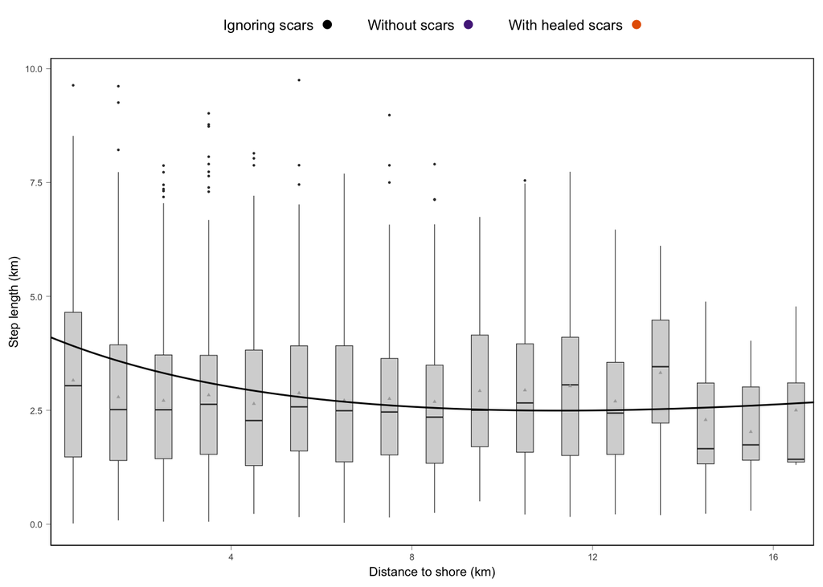

```r
mov.plot("noscars", healed= FALSE)
```

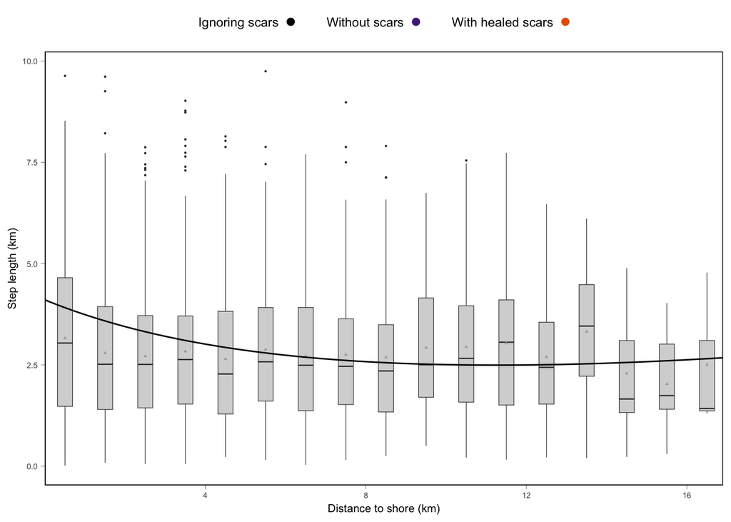

```r
mov.plot("sel.healed", healed= FALSE)
```

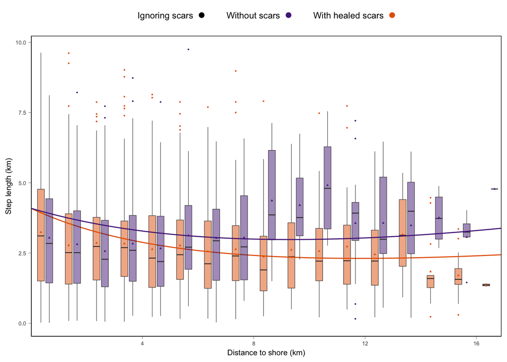

```r
mov.plot("mov.healed", healed= TRUE)
```

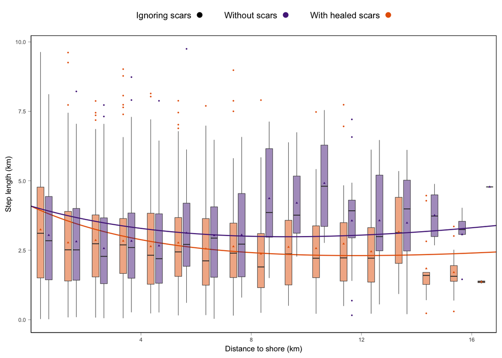

```r
mov.plot("mov.sel.healed", healed= TRUE)
```

# Map predictions

First create a distance to shore raster.

```r
rast.grid <- rast(extent = ext(narwhals.avail.sf),
                  nrows=150, ncols=150, crs = crs(land))
landR <- as.numeric(rasterize(land, rast.grid))
landR[is.na(landR)] <- 0

shore <- distance(landR, vect(land.1))/1000
names(shore) <- "distShore"

shore.w <- shore
shore.w[landR == 1] <- NA
```

Prediction map of SSF using the naive method (sensu Signer et al. 2017). Habitat selection coefficient * covariate. Below we will look at the utilization distribution (UD).

```r
ssf.map.noscars <- exp(summary(ssf.noscars)$coef$cond["distShore.end",1] * shore.w)
ssf.map.sel.healed.F <-
  exp((summary(ssf.sel.healed)$coef$cond["distShore.end",1] * shore.w))
ssf.map.sel.healed.T <-
  exp((summary(ssf.sel.healed)$coef$cond["distShore.end",1] * shore.w) +
        (summary(ssf.sel.healed)$coef$cond["distShore.end:Healed.Scars",1] * shore.w))
ssf.map.mov.healed <-
  exp(summary(ssf.mov.healed)$coef$cond["distShore.end",1] * shore.w)
ssf.map.mov.sel.healed.F <-
  exp((summary(ssf.mov.sel.healed)$coef$cond["distShore.end",1] * shore.w))
ssf.map.mov.sel.healed.T <-
  exp((summary(ssf.mov.sel.healed)$coef$cond["distShore.end",1] * shore.w) +
        (summary(ssf.mov.sel.healed)$coef$cond["distShore.end:Healed.Scars",1] * shore.w))


ssf.maps <- rast(list(noscars = ssf.map.noscars,
                      sel.healed.F = ssf.map.sel.healed.F,
                      sel.healed.T = ssf.map.sel.healed.T,
                      mov.healed = ssf.map.mov.healed,
                      mov.sel.healed.F = ssf.map.mov.sel.healed.F,
                      mov.sel.healed.T = ssf.map.mov.sel.healed.T))
```

Function to plot each plot separately.

```r
land.col <- "floralwhite"
ssf.min.col <- "#ffffcc"
ssf.mid.col <- "#41b6c4"
ssf.max.col <- "#0c2c84"

# For common colour bar
val.range <- range(as.data.frame(ssf.maps))

# Function for maps
mapping <- function(model.name, col.box){
  map <- ggplot() +
    geom_spatraster(data = ssf.maps[[model.name]]) +
    scale_fill_gradient2(low=ssf.min.col, mid=ssf.mid.col, high=ssf.max.col,
                      midpoint = mean(val.range), limit = val.range, na.value = NA) +
    geom_sf(data=land, fill=land.col) +
    coord_sf(xlim = c(st_bbox(ssf.maps[[model.name]])[1], st_bbox(ssf.maps[[model.name]])[3]),
           ylim = c(st_bbox(ssf.maps[[model.name]])[2], st_bbox(ssf.maps[[model.name]])[4]), expand = FALSE) +
    theme(panel.border = element_rect(colour = col.box, fill=NA, linewidth = 0.5),
          legend.title = element_text(size = rel(legend.text.size)),
          legend.text = element_text(size = rel(0.5)),
          legend.position = "top",
          axis.text = element_text(size = rel(0.5)),
          axis.ticks = element_line(colour = 'black', linewidth = 0.1)) +
    scale_y_continuous(breaks = seq(70, 80, by =1)) +
    scale_x_continuous(breaks = seq(-90, -80, by = 5)) +
    guides(fill = guide_colorbar(title = "SSF", order = 4,
                                 theme = theme(legend.title = element_text(size = rel(legend.text.size)),
                                               legend.position = "top"))) +
    theme(plot.margin = unit(plot.mar.l, 'lines'))
  return(map)
}
```

Example plot.

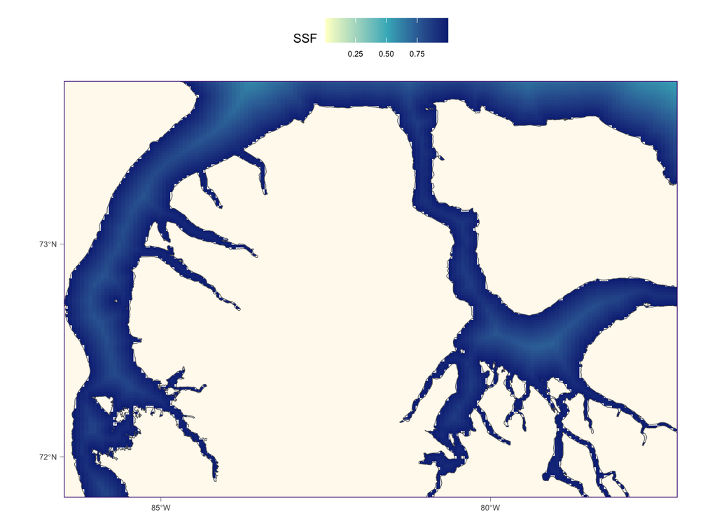

```r
mapping("sel.healed.F", pred.col["FALSE"])
```

Create legends.

```r
legend.plot.map <- as_ggplot(get_legend(mapping("mov.sel.healed.F", "black")))
legend.plot.mov <- as_ggplot(get_legend(mov.plot("mov.sel.healed",
                                                 healed = TRUE)))
```

## Alternative figure with both movement and habitat selection

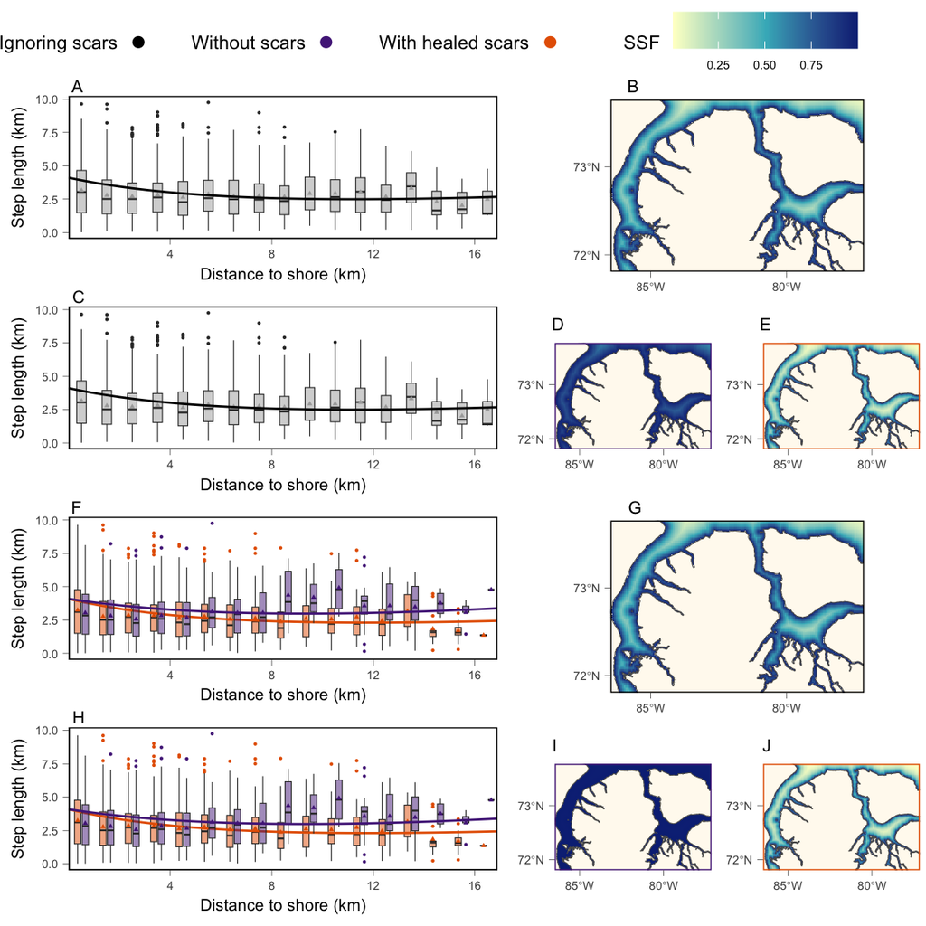

```r
ggarrange(
  ggarrange(legend.plot.mov, legend.plot.map, nrow = 1,
            widths = c(0.6, 0.4)),
  ggarrange(
    # Column 1 Model without healed scars
    ggarrange(mov.plot("noscars", healed= FALSE),
              mapping("noscars", "black"),
              nrow=1, legend = "none", widths = c(0.55, 0.45),
              labels = c("A", "B"), label.x = c(0.13, 0.27), label.y = 1.05,
              font.label = list(size = 8, face="plain")),
    ggarrange(mov.plot("sel.healed", healed= FALSE),
              mapping("sel.healed.F", pred.col["FALSE"]),
              mapping("sel.healed.T", pred.col["TRUE"]),
            nrow=1, legend = "none", widths = c(0.55, 0.225 ,0.225),
            labels = c("C", "D", "E"),
            label.x = c(0.13, rep(0.175, 2)), label.y = c(1.05, rep(0.92,2)),
            font.label = list(size = 8, face="plain")),
    ggarrange(mov.plot("mov.healed", healed= TRUE),
              mapping("mov.healed", "black"), nrow=1, legend = "none",
              widths = c(0.55,0.45),
              labels = c("F", "G"), label.x = c(0.13, 0.27), label.y = 1.05,
              font.label = list(size = 8, face="plain")),
    ggarrange(mov.plot("mov.sel.healed", healed= TRUE),
              mapping("mov.sel.healed.F", pred.col["FALSE"]),
              mapping("mov.sel.healed.T", pred.col["TRUE"]),
            nrow=1, legend = "none", widths = c(0.55, 0.225 ,0.225),
            labels = c("H", "I", "J"),
            label.x = c(0.13, rep(0.195, 2)), label.y = c(1.05, rep(0.92,2)),
            font.label = list(size = 8, face="plain")),
    ncol = 1),
  ncol = 1 , heights = c(0.1, 1)
)
```

# Utilization Distribution

```r
# Selects location that are on water
water_cells <- which(values(landR) == 0)
# Extract their corresponding coordinates in the raster
coords_proj <- xyFromCell(rast.grid, water_cells)
# Number of locations to evaluate to get the movement kernel that will be a n x n matrix
# row is start point and column is end point of the movement
n <- nrow(coords_proj)

# Derive distance to shore covariate
# Covariate that is used in all models: distance to shore
shore_vals <- values(shore.w)[water_cells]
# Each column has the same value: corresponding to the distance to shore at the end point
shore_vals_end <- matrix(shore_vals, nrow = n, ncol = n, byrow = TRUE)
# Each row as same value: corresponding to the distance to shore at the start point.
shore_vals_start <- matrix(shore_vals, nrow = n, ncol = n)

# Derive the matrix of step length:
# row i and col j corresponds to step length from ith location (start) -> jth location (end)
sf_points <- st_as_sf(as.data.frame(coords_proj),
                      coords = c("x", "y"), crs = chosen.proj)
step_length_matrix <- st_distance(sf_points, sf_points)/1000
step_length_matrix <- matrix(as.numeric(step_length_matrix),
                             nrow = nrow(step_length_matrix))
```

The movement depends on the individuals’ starting locations, so we use `shore_vals_start` as the matrix of covariates for the movement parameters. For each model, we now derive the associated movement parameters.

```r
# For Model 1: ssf.map.noscars
shape1 <- shape.ssf(b1_shape, ssf.noscars,
                    shore_vals_start)
scale1 <- scale.ssf(b2_scale, ssf.noscars,
                    shore_vals_start, healed=FALSE)


# For Model 2: ssf.map.sel.healed.F and ssf.map.sel.healed.T
shape2 <- shape.ssf(b1_shape, ssf.sel.healed,
                    shore_vals_start)
scale2 <- scale.ssf(b2_scale, ssf.sel.healed,
                    shore_vals_start, healed=FALSE)

# For Model 3: ssf.map.mov.healed
shape3_T <- shape.ssf(b1_shape, ssf.mov.healed,
                      shore_vals_start)
scale3_T <- scale.ssf(b2_scale, ssf.mov.healed,
                      shore_vals_start, healed=TRUE)

shape3_F <- shape.ssf(b1_shape, ssf.mov.healed,
                      shore_vals_start)
scale3_F <- scale.ssf(b2_scale, ssf.mov.healed,
                      shore_vals_start, healed=FALSE)


# For Model 4: ssf.map.movsel.healed
shape4_T <- shape.ssf(b1_shape, ssf.mov.sel.healed,
                      shore_vals_start)
scale4_T <- scale.ssf(b2_scale, ssf.mov.sel.healed,
                      shore_vals_start, healed=TRUE)

shape4_F <- shape.ssf(b1_shape, ssf.mov.sel.healed,
                     shore_vals_start)
scale4_F <- scale.ssf(b2_scale, ssf.mov.sel.healed,
                     shore_vals_start, healed=FALSE)
```

From it, we derive the matrix of step-length distribution for each model.

```r
step_prob_matrix1 <- dgamma(step_length_matrix,
                            shape = shape1, scale = scale1)
step_prob_matrix2 <- dgamma(step_length_matrix,
                            shape = shape2, scale = scale2)
step_prob_matrix3_T <- dgamma(step_length_matrix,
                              shape = shape3_T, scale = scale3_T)
step_prob_matrix3_F <- dgamma(step_length_matrix,
                              shape = shape3_F, scale = scale3_F)
step_prob_matrix4_T <- dgamma(step_length_matrix,
                              shape = shape4_T, scale = scale4_T)
step_prob_matrix4_F <- dgamma(step_length_matrix,
                              shape = shape4_F, scale = scale4_F)
```

We can now derive the movement kernel. Note that we do not incorporate turning angles, effectively ignoring directional correlation in the data. This simplification should introduce minimal bias because the effect of correlation becomes negligible when inferring long-term behaviour. As Hawkes (2009) observes “As sampling is carried out less frequently or after a large number of steps, CRW increasingly comes to resemble uncorrelated random walk (Okubo 1980). That is relevant in exploring the implications of the correlation identiﬁed in movement behaviour because CRW may generate distance distributions similar to or the same as those of uncorrelated random walk over time-scales relevant to dispersal”. In other words, over large scales and long time periods, the habitat use patterns of a correlated random walk are similar to those of an uncorrelated walk. Since the UD reflects the stationary equilibrium of habitat use patterns, neglecting the correlation in movement data when estimating it, should only introduce minimal bias.

Additionally, including turning angles would increase the dimensionality of the transition matrix, making it an n x n x M array, where $M$ refers to the number of discrete bins used to represent the possible angles from $0$ to $2\pi$. This would make matrix inversion computationally infeasible, so ignoring turning angles is both theoretically reasonable and practically necessary.

```r
movkernel_matrix <- step_prob_matrix1*
  exp(summary(ssf.noscars)$coef$cond["distShore.end",1]*shore_vals_end)
col_sums <- colSums(movkernel_matrix)
movkernel_matrix_norm1 <- t(t(movkernel_matrix)) / col_sums
```

```r
#  Healed False
movkernel_matrix2_F <- step_prob_matrix2*
  exp((summary(ssf.sel.healed)$coef$cond["distShore.end",1] * shore_vals_end))
col_sums <- colSums(movkernel_matrix2_F)
movkernel_matrix2_F_norm <- t(t(movkernel_matrix2_F) / col_sums)

#  Healed True
movkernel_matrix2_T <- step_prob_matrix2*
  exp((summary(ssf.sel.healed)$coef$cond["distShore.end",1] * shore_vals_end) +
        (summary(ssf.sel.healed)$coef$cond["distShore.end:Healed.Scars",1] * shore_vals_end))
col_sums <- colSums(movkernel_matrix2_T)
movkernel_matrix2_T_norm <- t(t(movkernel_matrix2_T) / col_sums)
```

```r
#  Healed False
movkernel_matrix3_F <- step_prob_matrix3_F*
  exp(summary(ssf.mov.healed)$coef$cond["distShore.end",1] * shore_vals_end)
col_sums <- colSums(movkernel_matrix3_F)
movkernel_matrix3_F_norm <-  t(t(movkernel_matrix3_F) / col_sums)

#  Healed True
movkernel_matrix3_T <- step_prob_matrix3_T*
  exp(summary(ssf.mov.healed)$coef$cond["distShore.end",1] * shore_vals_end)
col_sums <- colSums(movkernel_matrix3_T)
movkernel_matrix3_T_norm <- t(t(movkernel_matrix3_T) / col_sums)
```

```r
#  Healed False
movkernel_matrix4_F <- step_prob_matrix4_F*
  exp(summary(ssf.mov.sel.healed)$coef$cond["distShore.end",1] * shore_vals_end)
col_sums <- colSums(movkernel_matrix4_F)
movkernel_matrix4_F_norm <- t(t(movkernel_matrix4_F) / col_sums)

#  Healed True
movkernel_matrix4_T <- step_prob_matrix4_T*
  exp((summary(ssf.mov.sel.healed)$coef$cond["distShore.end",1] * shore_vals_end) +
        (summary(ssf.mov.sel.healed)$coef$cond["distShore.end:Healed.Scars",1] * shore_vals_end))
col_sums <- colSums(movkernel_matrix4_T)
movkernel_matrix4_T_norm <-  t(t(movkernel_matrix4_T) / col_sums)
```

```r
get_eigenraster <- function(movkernel_matrix){
# Compute the eigenvector corresponding to the eigenvalue closest to 1
res <- eigs(movkernel_matrix, k = 1, sigma = 1)

eigenvalue <- res$values
eigenvector <- res$vectors
eigenvector <- eigenvector / sum(eigenvector)
eigen_raster1 <- rast.grid


values(eigen_raster1) <- NA

# Assign eigenvector values to the water cells
eigen_raster1[water_cells] <- Re(eigenvector)

# Normalize again
values(eigen_raster1)[water_cells] <- values(eigen_raster1)[water_cells] /
                                     sum(values(eigen_raster1)[water_cells], na.rm = TRUE)
return(eigen_raster1)
}
```

```r
eigen_raster1 <- get_eigenraster(movkernel_matrix_norm1)
eigen_raster2_F <- get_eigenraster(movkernel_matrix2_F_norm)
eigen_raster2_T <- get_eigenraster(movkernel_matrix2_T_norm)
eigen_raster3_F <- get_eigenraster(movkernel_matrix3_F_norm)
eigen_raster3_T <- get_eigenraster(movkernel_matrix3_T_norm)
eigen_raster4_F <- get_eigenraster(movkernel_matrix4_F_norm)
eigen_raster4_T <- get_eigenraster(movkernel_matrix4_T_norm)
```

```r
ud.rasters <- list(
  noscars = eigen_raster1,
  sel.healed.F = eigen_raster2_F,
  sel.healed.T = eigen_raster2_T,
  mov.healed.F = eigen_raster3_F,
  mov.healed.T = eigen_raster3_T,
  sel.mov.healed.T = eigen_raster4_T,
  sel.mov.healed.F = eigen_raster4_F
)
```

Function to map UDs.

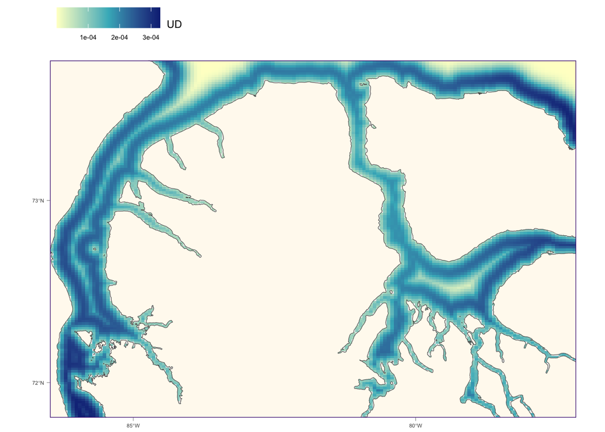

```r
val.range.UD <- range(as.data.frame(ud.rasters))
mapping.UD <- function(model.name, col.box, plot.mar.l.UD = c(0.045, 0, 0.2, 0.2), y.axis.inc = TRUE){
  if(y.axis.inc){
    axis.text.y <- element_text(size = rel(0.5))
    axis.ticks.y <- element_line(colour = 'black', linewidth = 0.1)
  }else{
    plot.mar.l.UD[4] <- 0
    axis.text.y <- element_blank()  # Removes the tick mark labels (the numbers)
    axis.ticks.y <- element_blank()
  }
  map <- ggplot() +
    geom_spatraster(data = ud.rasters[[model.name]]) +
    scale_fill_gradient2(low=ssf.min.col, mid=ssf.mid.col, high=ssf.max.col,
                      midpoint = mean(val.range.UD), limit = val.range.UD, na.value = NA) +
    geom_sf(data=land, fill=land.col) +
    coord_sf(xlim = c(st_bbox(ud.rasters[[model.name]])[1], st_bbox(ud.rasters[[model.name]])[3]),
           ylim = c(st_bbox(ud.rasters[[model.name]])[2], st_bbox(ud.rasters[[model.name]])[4]), expand = FALSE) +
    theme(panel.border = element_rect(colour = col.box, fill = NA, linewidth = 0.5),
          legend.title = element_text(size = rel(legend.text.size)),
          legend.text = element_text(size = rel(0.5)),
          legend.position = "top",
          legend.justification = "left",
          axis.text.x = element_text(size = rel(0.5)),
          axis.ticks.x = element_line(colour = 'black', linewidth = 0.1),
          axis.text.y = axis.text.y,
          axis.ticks.y =  axis.ticks.y) +
    scale_y_continuous(breaks = seq(70, 80, by =1)) +
    scale_x_continuous(breaks = seq(-90, -80, by = 5)) +
    guides(fill = guide_colorbar(title = "UD",
                                 order = 4,
                                 title.position = "right",
                                 theme = theme(legend.title =
                                                 element_text(size = rel(legend.text.size)),
                                               legend.position = "top"))) +
    theme(plot.margin = unit(plot.mar.l.UD, 'lines'))
  return(map)
}

mapping.UD("sel.healed.F", pred.col["FALSE"])
```

Create legend for UD.

```r
legend.plot.map.ud <- as_ggplot(get_legend(mapping.UD("sel.healed.F", "black")))
```

Function to map the difference between the UDs of narwhals with and without scars.

```r
mapping.UD.diff <- function(raster.dif,
                            col.box = "black",
                            plot.mar.l.UD = c(0.045, 0, 0.2, 0.2),
                            y.axis.inc = TRUE, limits = NULL){
  if(is.null(limits)){
    limits <- range(as.matrix(raster.dif), na.rm = TRUE)
  }


  if(y.axis.inc){
    axis.text.y <- element_text(size = rel(0.5))
    axis.ticks.y <- element_line(colour = 'black', linewidth = 0.1)
  }else{
    plot.mar.l.UD[4] <- 0
    axis.text.y <- element_blank()  # Removes the tick mark labels (the numbers)
    axis.ticks.y <- element_blank()
  }
  map <- ggplot() +
    geom_spatraster(data = raster.dif) +
    scale_fill_gradient2(low = ssf.min.col.diff,
                         mid = ssf.mid.col.diff,
                         high = ssf.max.col.diff, na.value = NA,
                         midpoint = 0, limits = limits,
                         breaks = scales::pretty_breaks(n = 3),
                         labels = function(x) {
                           sapply(x, function(v) {
                             if (v < 0) {paste0(v, "\n\nScarred")
                             } else if (v > 0) {
                               paste0(v, "\n\nUnscarred")
                                 } else {paste0(v, "\nUsed more by")}})}) +
    geom_sf(data=land, fill=land.col) +
    coord_sf(xlim = c(st_bbox(raster.dif)[1], st_bbox(raster.dif)[3]),
           ylim = c(st_bbox(raster.dif)[2], st_bbox(raster.dif)[4]), expand = FALSE) +
    theme(panel.border = element_rect(colour = col.box, fill = NA,
                                      linewidth = 0.5),
          legend.title = element_text(size = rel(legend.text.size)),
          legend.text = element_text(size = rel(0.5)),
          legend.justification = "left",
          legend.position = "top",
          axis.text.x = element_text(size = rel(0.5)),
          axis.ticks.x = element_line(colour = 'black', linewidth = 0.1),
          axis.text.y = axis.text.y,
          axis.ticks.y =  axis.ticks.y) +
    scale_y_continuous(breaks = seq(70, 80, by =1)) +
    scale_x_continuous(breaks = seq(-90, -80, by = 5)) +
    guides(fill = guide_colorbar(title = "Diff. in UD \n\n",
                                 order = 4,
                                 title.position = "right",
                                 theme = theme(legend.title =
                                                 element_text(size = rel(legend.text.size)),
                                               legend.position = "top"))) +
    theme(plot.margin = unit(plot.mar.l.UD, 'lines'))
  return(map)
}
```

Identify the range of values in the difference in UD.

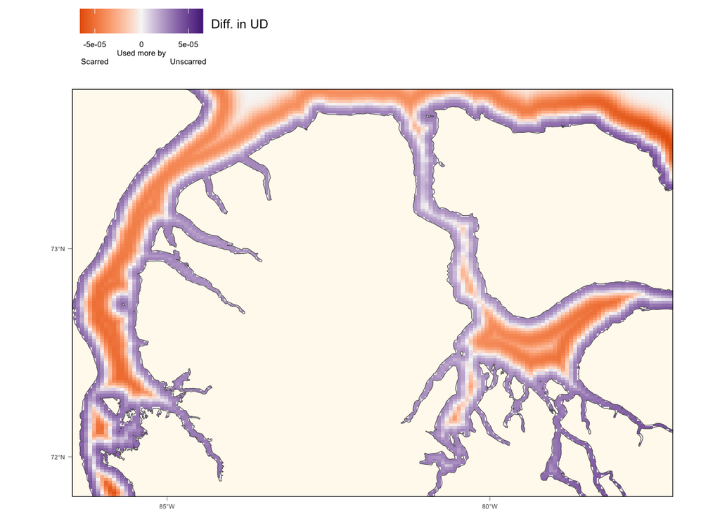

```r
ud.diff.range <- range(
  c(as.matrix(eigen_raster2_F - eigen_raster2_T),
    as.matrix(eigen_raster3_F - eigen_raster3_T),
    as.matrix(eigen_raster4_F - eigen_raster4_T)), na.rm = TRUE)
# Make it same length on both side
ud.diff.range <- c(-max(abs(ud.diff.range)), max(abs(ud.diff.range)))
mapping.UD.diff(eigen_raster3_F - eigen_raster3_T, limits = ud.diff.range)
```

Create legend for UD diff.

```r
legend.plot.map.ud.diff <- as_ggplot(get_legend(
  mapping.UD.diff(eigen_raster2_F - eigen_raster2_T, limits = ud.diff.range)))
```

Final figure.

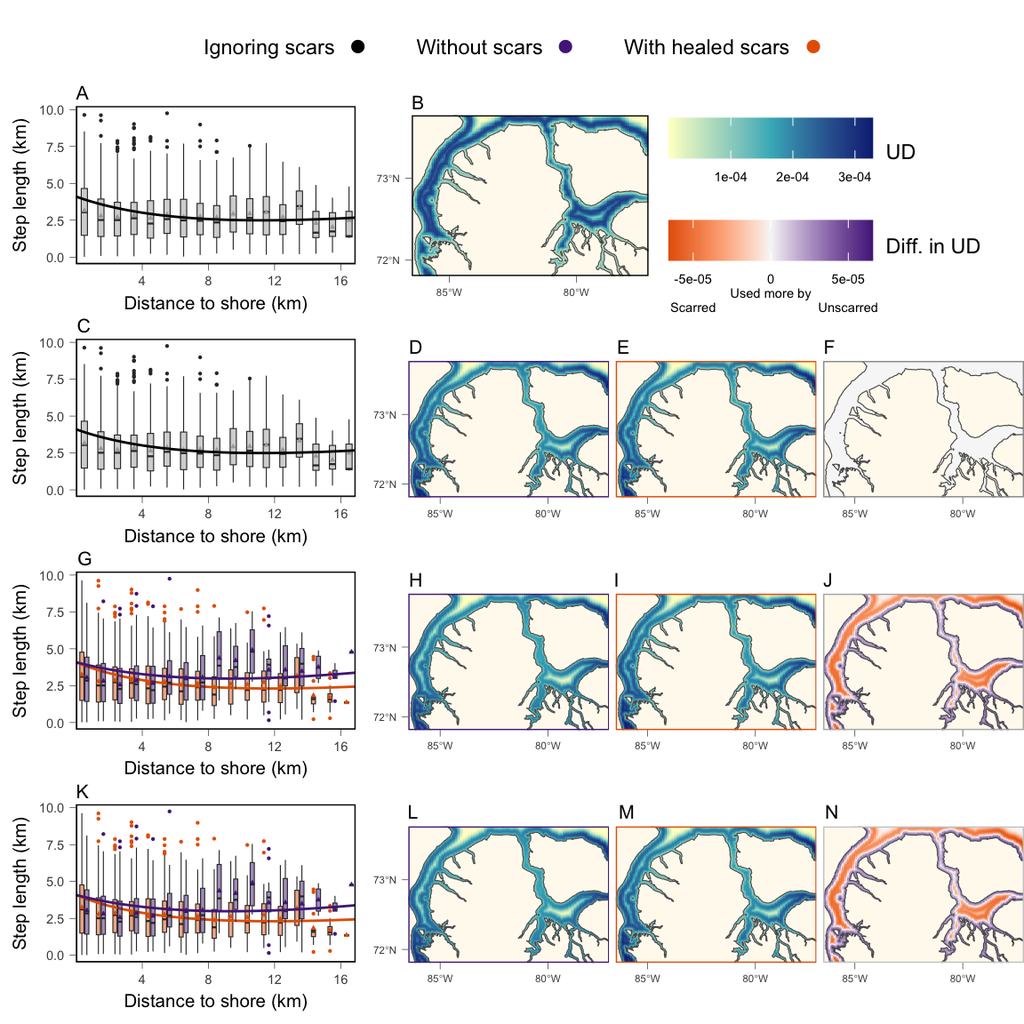

```r
main_plot <- ggarrange(
  legend.plot.mov,
    ggarrange(
      # Columns 1-2/Row 1 Model without healed scars + legends
      ggarrange(mov.plot("noscars", healed= FALSE),
              mapping.UD("noscars", "black",
                         plot.mar.l.UD = c(0.3, 0.2, 0.5, 0.3)),
              ggarrange(legend.plot.map.ud,
                        legend.plot.map.ud.diff,
                        nrow = 2),
              nrow = 1, legend = "none", widths = c(0.36, 0.28, 0.36),
              labels = c("A", "B"),
              label.x = c(0.19, 0.128),
              label.y = c(1.06, 1.02),
              font.label = list(size = 8, face="plain")),
      # Columns 1-2/Row 2 Model with healed scars in selection
      ggarrange(mov.plot("sel.healed", healed = FALSE),
              mapping.UD("sel.healed.F", pred.col["FALSE"]),
              mapping.UD("sel.healed.T", pred.col["TRUE"], y.axis.inc = FALSE),
              mapping.UD.diff(eigen_raster2_F - eigen_raster2_T,
                              col.box = grey(0.6),
                              y.axis.inc = FALSE, limits = ud.diff.range),
              nrow = 1, legend = "none",
              widths =  c(0.36, 0.235, 0.2025, 0.2025),
              labels = c("C", "D", "E", "F"),
              label.x = c(0.19, 0.14, rep(0.007, 2)),
              label.y = c(1.06, rep(0.97, 3)),
              font.label = list(size = 8, face="plain")),
      # Columns 1-2/Row 3 Model with healed scars in movement
      ggarrange(mov.plot("mov.healed", healed = TRUE),
              mapping.UD("mov.healed.F", pred.col["FALSE"]),
              mapping.UD("mov.healed.T", pred.col["TRUE"], y.axis.inc = FALSE),
              mapping.UD.diff(eigen_raster3_F - eigen_raster3_T,
                              col.box = grey(0.7),
                              y.axis.inc = FALSE, limits = ud.diff.range),
              nrow = 1, legend = "none",
              widths =  c(0.36, 0.235, 0.2025, 0.2025),
              labels = c("G", "H", "I", "J"),
              label.x = c(0.19, 0.14, rep(0.009, 2)),
              label.y = c(1.06, rep(0.97, 3)),
              font.label = list(size = 8, face="plain")),
      # Columns 1-2/Row 4 Model with healed scars in both
      ggarrange(mov.plot("mov.sel.healed", healed = TRUE),
              mapping.UD("sel.mov.healed.F", pred.col["FALSE"]),
              mapping.UD("sel.mov.healed.T", pred.col["TRUE"],
                         y.axis.inc = FALSE),
              mapping.UD.diff(eigen_raster4_F - eigen_raster4_T,
                              col.box = grey(0.8),
                              y.axis.inc = FALSE, limits = ud.diff.range),
              nrow = 1, legend = "none",
              widths =  c(0.36, 0.235, 0.2025, 0.2025),
              labels = c("K", "L", "M", "N"),
              label.x = c(0.19, 0.14, rep(0.008, 2)),
              label.y = c(1.06, rep(0.97, 3)),
              font.label = list(size = 8, face="plain")),
      ncol = 1),
  ncol = 1 , heights = c(0.1, 1)
)
main_plot
```

# Literature cited

Avgar, T., Potts, J. R., Lewis, M. A. & Boyce, M. S. (2016). Integrated step selection analysis: bridging the gap between resource selection and animal movement. Methods in Ecology and Evolution, 7, 619–630. https://doi.org/10.1111/2041-210X.12528

Hawkes, C. (2009). Linking movement behaviour, dispersal and population processes: is individual variation a key? Journal of Animal Ecology, 78, 894-906. https://doi.org/10.1111/j.1365-2656.2009.01534.x

Muff, S., Signer, J., & Fieberg J. (2020). Accounting for individual-specific variation in habitat-selection studies: Efficient estimation of mixed-effects models using Bayesian or frequentist computation. J Anim Ecol, 89, 80–92. https://doi.org/10.1111/1365-2656.13087

Okubo, A. (1980). Diffusion and ecological problems: mathematical models. Springer, New York.

Potts, J. R., & Börger, L. (2023). How to scale up from animal movement decisions to spatiotemporal patterns: An approach via step selection. Journal of Animal Ecology, 92, 16-29. https://doi.org/10.1111/1365-2656.13832

Signer, J., Fieberg , & Avgar T. (2017). Estimating utilization distributions from fitted step-selection functions. Ecosphere 8, e01771. https://doi.org/10.1002/ecs2.1771